# Multivariate Results

# Checking if conditions need collapsed

## Stereotyping outcome

```r
# Number of effect sizes per comparison we coded
k_per_comparison <- meta_data %>%
  dplyr::select(dunb, pt_comparison, outcome_type) %>%
  unique() %>%
  group_by(pt_comparison, outcome_type) %>%
  count() %>% mutate(pt_comparison = dplyr::recode(pt_comparison,
                                `1` = "Self PT vs Day control",
                                `2` = "Self PT vs Other control",
                                `3` = "Self PT vs Objective",
                                `4` = "Self PT vs Suppression",
                                `5` = "Other PT vs Day control",
                                `6` = "Other PT vs Other control",
                                `7` = "Other PT vs Objective",
                                `9` = "Other PT vs Self PT",
                                `10` = "PT US vs Day control",
                                `11` = "PT US vs other control",
                                `12` = "PT US vs Objective",
                                `13` = "PT US vs Suppression"))

# For stereotyping outcome
k_per_comparison %>%
  filter(outcome_type == 1)
```

```
## # A tibble: 12 x 3
## # Groups:   pt_comparison, outcome_type [12]
##    pt_comparison             outcome_type     n
##    <fct>                     <fct>        <int>
##  1 Self PT vs Day control    1               30
##  2 Self PT vs Other control  1               13
##  3 Self PT vs Objective      1               33
##  4 Self PT vs Suppression    1                1
##  5 Other PT vs Day control   1                5
##  6 Other PT vs Other control 1               24
##  7 Other PT vs Objective     1               30
##  8 Other PT vs Self PT       1                9
##  9 PT US vs Day control      1                2
## 10 PT US vs other control    1                9
## 11 PT US vs Objective        1                7
## 12 PT US vs Suppression      1                2
```

Our pre-registered rule was that there must be k = 20 per cell. As this does not apply to every relevant cell, we will need to collapse until we reach this. Also, for the prelims analysis, we will not be adding in perspective taking unspecified (PTUS), but will be adding that to relevant comparisons to see if it affects the analyses for published versions. Also, for all analyses in addition to the meta-analyses specified below, we will conduct moderator analyses with sample size and target information.

For stereotyping, we will do the following:

- Drop any comparison including suppression, as there are not enough even when collapsed (k = 3).
- We will fun analyses using two of the following comparisons to get at different theoretical comparisons:
  - We will collapse across the “Day in the life” and “Other” control conditions. This will allow us to analyze Imagine-self versus Imagine-other perspective taking in comparison to a broad control and the objective comparison condition.
  - We will then collapse across Imagine-self and Imagine-other to examine the if there is difference between the effect of perspective taking instructions when the comparison is the “Day in the life control” versus “Other control” or objective comparison.

## Merging/Overlap outcome

```r
# For overlap/merging outcome
k_per_comparison %>%
  filter(outcome_type == 2)
```

```
## # A tibble: 9 x 3
## # Groups:   pt_comparison, outcome_type [9]
##   pt_comparison             outcome_type     n
##   <fct>                     <fct>        <int>
## 1 Self PT vs Day control    2                5
## 2 Self PT vs Other control  2                5
## 3 Self PT vs Objective      2               13
## 4 Self PT vs Suppression    2                5
## 5 Other PT vs Day control   2                4
## 6 Other PT vs Other control 2                8
## 7 Other PT vs Objective     2               18
## 8 Other PT vs Self PT       2                7
## 9 PT US vs other control    2                4
```

Due to the lower number of studies in this outcome category, we will have to collapse across both Imagine-self and Imagine-other perspective taking instructions as well as “Day in the life” and “Other control” comparisons. As this is the most limiting of the outcomes, we will have to collapse this same way in all outcome categories for the overall meta-analysis when we will include outcome as a predictor.

## Interpersonal feelings outcome

```r
# For interpersonal feelings
k_per_comparison %>%
  filter(outcome_type == 3)
```

```
## # A tibble: 9 x 3
## # Groups:   pt_comparison, outcome_type [9]
##   pt_comparison             outcome_type     n
##   <fct>                     <fct>        <int>
## 1 Self PT vs Day control    3                8
## 2 Self PT vs Other control  3               27
## 3 Self PT vs Objective      3               19
## 4 Other PT vs Other control 3               70
## 5 Other PT vs Objective     3               62
## 6 Other PT vs Self PT       3               17
## 7 PT US vs Day control      3                1
## 8 PT US vs other control    3                4
## 9 PT US vs Objective        3                1
```

We will have to collapse across across “day in the life” and “other” control conditions. As our “Self PT versus Objective” is only one study under our pre-registered limit - and this is a preliminary analysis for a doctoral requirement - we will include that category for this analysis with the expectation that when we include regression coefficients and data from contacted authors, it will be over our limit (spoiler alert: it will). Therefore, for the analysis specifically examining interpersonal feelings outcomes, we will not collapse across Imagine-self and Imagine-other instruction comparisons.

# Descriptive Data Check

## Histograms

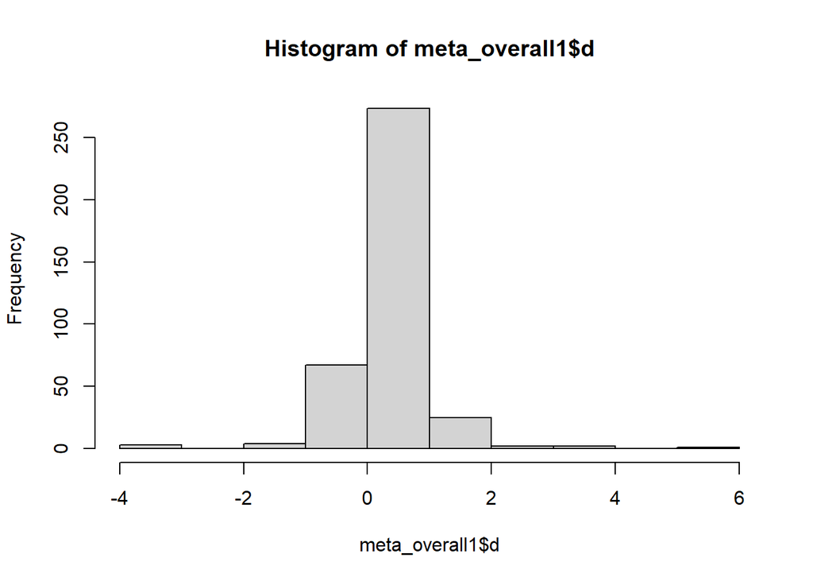

```r
hist(meta_overall1$d)
```

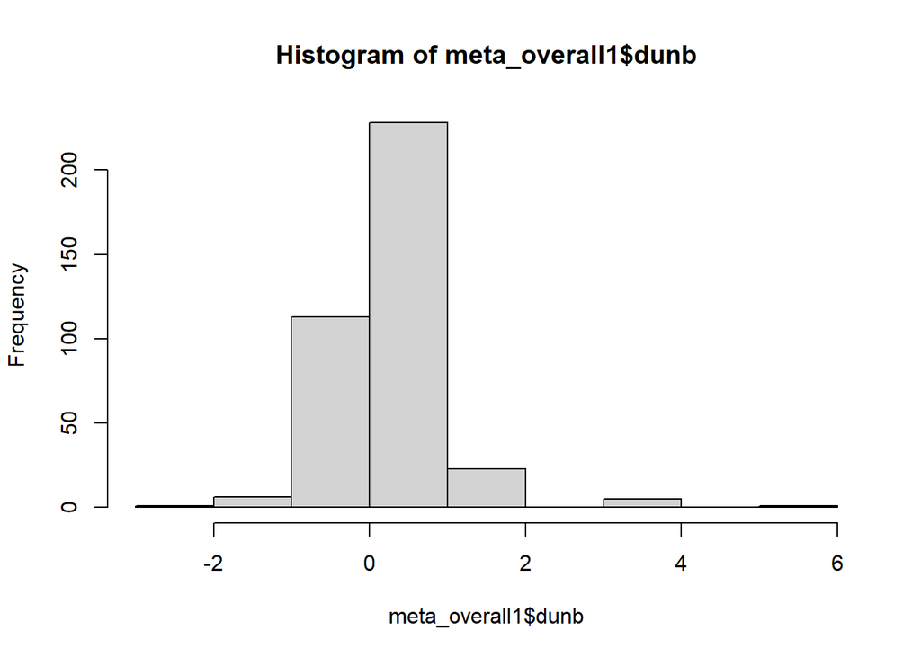

```r
hist(meta_overall1$dunb)
```

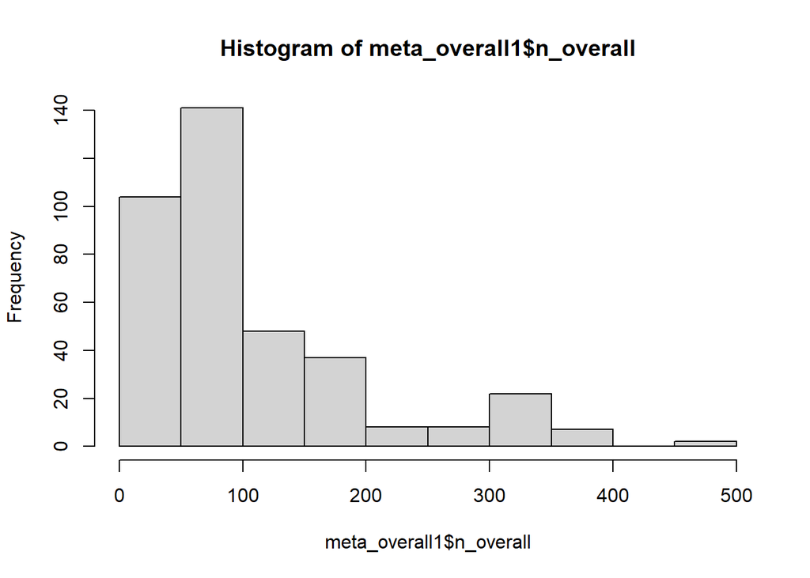

```r
hist(meta_overall1$n_overall)
```

## Descriptives

```r
descrip_data <- meta_overall1 %>%
  select(d, dunb, var, var_dunb, authors, outcomes_within_sample_var, pt_comparison, outcome_type, outcome_scale_group, target_information, target_ingroup_nonspecific, target_out_minor, target_adversary, target_empathetic_need, n_overall)

psych::describe(descrip_data)
```

```
##                             vars   n   mean    sd median trimmed   mad   min
## d                              1 377   0.37  0.70   0.36    0.37  0.45 -3.54
## dunb                           2 377   0.28  0.73   0.24    0.25  0.57 -2.86
## var                            3 377   0.07  0.05   0.06    0.06  0.04  0.01
## var_dunb                       4 377   0.06  0.05   0.06    0.06  0.04  0.01
## authors*                       5 377  35.90 22.31  36.00   35.47 26.69  1.00
## outcomes_within_sample_var     6 377   2.05  1.38   2.00    1.80  1.48  1.00
## pt_comparison*                 7 377   1.54  0.50   2.00    1.54  0.00  1.00
## outcome_type*                  8 377   1.87  0.92   2.00    1.84  1.48  1.00
## outcome_scale_group*           9 377   8.20  3.81   9.00    8.29  4.45  1.00
## target_information*           10 377   2.16  0.76   2.00    2.20  1.48  1.00
## target_ingroup_nonspecific*   11 372   1.80  0.44   2.00    1.86  0.00  1.00
## target_out_minor*             12 374   1.68  0.47   2.00    1.73  0.00  1.00
## target_adversary*             13 374   1.84  0.37   2.00    1.92  0.00  1.00
## target_empathetic_need        14 374   1.47  0.50   1.00    1.46  0.00  1.00
## n_overall                     15 377 110.76 90.91  75.00   93.27 50.41 20.00
##                                max  range  skew kurtosis   se
## d                             5.28   8.81  0.23    13.91 0.04
## dunb                          5.25   8.11  1.53     9.38 0.04
## var                           0.25   0.24  1.36     1.79 0.00
## var_dunb                      0.24   0.23  1.31     1.65 0.00
## authors*                     74.00  73.00  0.06    -1.19 1.15
## outcomes_within_sample_var    9.00   8.00  1.52     2.49 0.07
## pt_comparison*                2.00   1.00 -0.14    -1.98 0.03
## outcome_type*                 3.00   2.00  0.25    -1.77 0.05
## outcome_scale_group*         15.00  14.00 -0.18    -1.22 0.20
## target_information*           3.00   2.00 -0.28    -1.22 0.04
## target_ingroup_nonspecific*   3.00   2.00 -0.85     0.37 0.02
## target_out_minor*             2.00   1.00 -0.79    -1.38 0.02
## target_adversary*             2.00   1.00 -1.84     1.40 0.02
## target_empathetic_need        2.00   1.00  0.14    -1.99 0.03
## n_overall                   485.00 465.00  1.63     2.14 4.68
```

This all looks correct

```r
cor_data <- descrip_data %>%
  select(d, dunb, var, var_dunb, n_overall)

cor(cor_data)
```

```
##                     d        dunb         var    var_dunb   n_overall
## d          1.00000000  0.14194055  0.09456576  0.09784288 -0.11252173
## dunb       0.14194055  1.00000000  0.28024754  0.28646459 -0.09725651
## var        0.09456576  0.28024754  1.00000000  0.99965666 -0.68282242
## var_dunb   0.09784288  0.28646459  0.99965666  1.00000000 -0.69115974
## n_overall -0.11252173 -0.09725651 -0.68282242 -0.69115974  1.00000000
```

- Is it weird that d and dunb are only slightly correlated, while var and var_dunb are almost 100%? Does this matter?
- Makes sense that variance is negatively correlated with sample size, as variance gets smaller as sample size increases and, thus, they have an inverse relationship.

## Boxplot

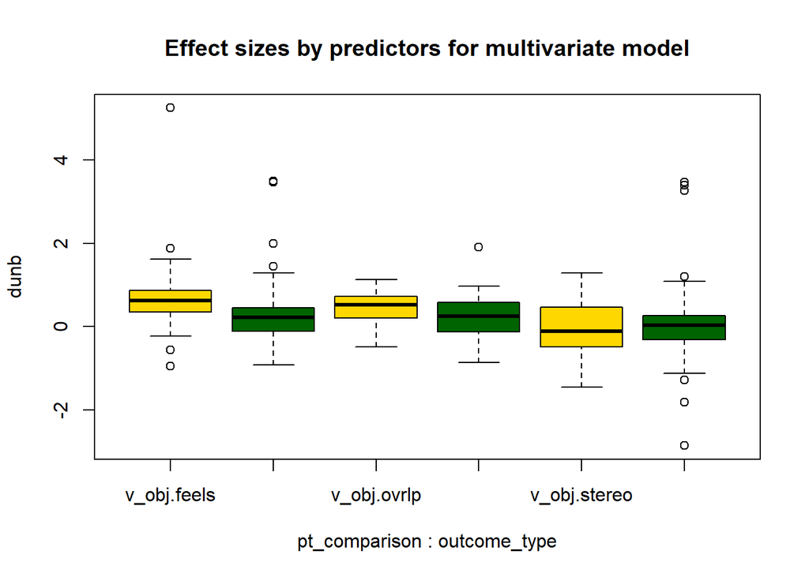

```r
descrip_data %<>%
  mutate(pt_comparison = dplyr::recode(pt_comparison,
                                       `pt_v_objective` = "v_obj",
                                       `pt_v_control` = "v_ctrl"),
         outcome_type = dplyr::recode(outcome_type,
                                      `Interpersonal Feels` = "feels",
                                      `Overlap` = "ovrlp",
                                      `Stereotyping` = "stereo"))

boxplot(dunb ~ pt_comparison*outcome_type, data = descrip_data,
        col = (c("gold", "darkgreen")),
        main = "Effect sizes by predictors for multivariate model")
```

There are some outlier data points, which was also indicated by the histogram. Check out those that are >= 2 or -2 below to see if they were coded incorrectly by us or in the effect size conversion errored.

## Checking Outliers

**Conclusion based on checks below: The outliers are correctly coded and there are not errors in the analysis. This appears to be valid data that passed our inclusion criteria and, therefore, should be included in the analysis.**

### Outliers >= 2 or -2

```r
out_dat <- meta_overall1 %>%
  filter(dunb >= 2 | dunb <= -2) #7 studies with outliers this large
```

All effect sizes were hand calculated by us using escalc in batches, so going to check that looks normal.

### Checking the first effect size (Abbate et al)

#### Checking escalc with individual data point

```r
abbate_eff4_check <- escalc(measure = "SMD", m1i = 1.75, m2i = 3.08, sd1i = 0.36, sd2i = 0.4, n1i = 24, n2i = 19, vtype = "UB") #exactly the same using individual code as running in group
```

It is identical

#### Hand calculating

```r
d_num <- (1.75-3.08)
sd_pool <- sqrt((.36^2+.4^2)/2)


d <- d_num/sd_pool
d
```

```
## [1] -3.495162
```

Slight variation, but pretty much the same - escalc seems to be doing things correctly. Overall, not a problem in the calculation leading to thsi outlier.

### Checking conversions from r (Shih et al; effet size 329)

Entered the data into this website and it was exactly the same: https://www.escal.site/

### Hand calculation

```r
d = 2*.87/ sqrt(1 - .87^2)
d
```

```
## [1] 3.529042
```

Also roughly the same - it appears the calculation is correct. The correlation is VERY large, so this makes sense. Need to re-check the data (for the 5th time) from the articles to see if what we have in the data is correct.

### Checked data from articles

**Looked to see if data was correct that was pulled from the papers:**

Abbate et al - correct Edwards et al - correct Lopez-Perez et al - correct Shih et al (effect size 329) - correct Shih et al (effect size 331) - correct Skorinko & Sinclair (360, 361) - correct; these are where we separated an interaction and calculated main effects per subset (stereotypical and less stereotypical stimuli participants)

# Descriptive info

## Number of papers

```r
meta_overall1 %>%
  dplyr::select(authors) %>%
  unique() %>%
  count()
```

```
## # A tibble: 1 x 1
##       n
##   <int>
## 1    74
```

## Number of studies

**Some papers had multiple studies.**

```r
meta_overall1 %>%
  dplyr::select(study_num_total) %>%
  unique() %>%
  count()
```

```
## # A tibble: 1 x 1
##       n
##   <int>
## 1   120
```

## Number of samples

**Some studies samples were separated based on different participant groups due to other variables (e.g., different cultures).**

```r
meta_overall1 %>%
  dplyr::select(sample_number_total) %>%
  unique() %>%
  count()
```

```
## # A tibble: 1 x 1
##       n
##   <int>
## 1   138
```

## Unique effect sizes

```r
meta_overall1 %>%
  dplyr::select(effect_size_num) %>%
  unique() %>%
  count()
```

```
## # A tibble: 1 x 1
##       n
##   <int>
## 1   377
```

## Average n per cell

**To be used in power analysis**

```r
meta_overall1 %>%
  dplyr::select(n_pt, n_comparison) %>%
  unique() %>%
  summarise(mean(n_pt),
            mean(n_comparison))
```

```
## # A tibble: 1 x 2
##   `mean(n_pt)` `mean(n_comparison)`
##          <dbl>                <dbl>
## 1         59.3                 58.6
```

## Effect sizes per outcome category

```r
meta_overall1 %>%
  dplyr::select(dunb, outcome_type) %>%
  unique() %>%
  group_by(outcome_type) %>%
  count() %>%
  mutate(outcome_type = dplyr::recode(outcome_type,
                               `1` = "Stereotyping/Bias",
                               `2` = "Overlap/Merging",
                               `3` = "Interpersonal Feelings"))
```

```
## # A tibble: 3 x 2
## # Groups:   outcome_type [3]
##   outcome_type            n
##   <fct>               <int>
## 1 Interpersonal Feels   185
## 2 Overlap                53
## 3 Stereotyping          135
```

## Effect sizes per comparison and outcome category

```r
meta_overall1 %>%
  dplyr::select(dunb, pt_comparison, outcome_type) %>%
  unique() %>%
  group_by(pt_comparison, outcome_type) %>%
  count()
```

```
## # A tibble: 6 x 3
## # Groups:   pt_comparison, outcome_type [6]
##   pt_comparison  outcome_type            n
##   <fct>          <fct>               <int>
## 1 pt_v_objective Interpersonal Feels    81
## 2 pt_v_objective Overlap                31
## 3 pt_v_objective Stereotyping           63
## 4 pt_v_control   Interpersonal Feels   105
## 5 pt_v_control   Overlap                22
## 6 pt_v_control   Stereotyping           72
```

# Overall Multivariate Meta-analysis

## Model results

**Contrasts:**

```r
contrasts(meta_overall1$outcome_type)
```

```
##                     Overlap Stereotyping
## Interpersonal Feels       0            0
## Overlap                   1            0
## Stereotyping              0            1
```

### Nesting effect size within sample x outcome scale of measurement

```r
meta_multi1 <- rma.mv(dunb,
                      var_dunb,
                      mods = ~ pt_comparison*outcome_type,
                      random = list(~ 1 | sample_number_total/outcomes_within_sample_var,
                                    ~ 1 | outcome_scale_group),
                      data = meta_overall1)

meta_multi1
```

```
##
## Multivariate Meta-Analysis Model (k = 377; method: REML)
##
## Variance Components:
##
##             estim    sqrt  nlvls  fixed
## sigma^2.1  0.1837  0.4286    138     no
## sigma^2.2  0.1502  0.3875    280     no
## sigma^2.3  0.0515  0.2268     15     no
##                                                    factor
## sigma^2.1                             sample_number_total
## sigma^2.2  sample_number_total/outcomes_within_sample_var
## sigma^2.3                             outcome_scale_group
##
## Test for Residual Heterogeneity:
## QE(df = 371) = 2120.0554, p-val < .0001
##
## Test of Moderators (coefficients 2:6):
## QM(df = 5) = 41.6073, p-val < .0001
##
## Model Results:
##
##                                                     estimate      se     zval
## intrcpt                                               0.5233  0.1198   4.3672
## pt_comparisonpt_v_control                            -0.2476  0.0431  -5.7477
## outcome_typeOverlap                                  -0.1803  0.2070  -0.8710
## outcome_typeStereotyping                             -0.6028  0.1715  -3.5154
## pt_comparisonpt_v_control:outcome_typeOverlap         0.1968  0.0894   2.2014
## pt_comparisonpt_v_control:outcome_typeStereotyping    0.3154  0.1078   2.9255
##                                                       pval    ci.lb    ci.ub
## intrcpt                                             <.0001   0.2884   0.7581
## pt_comparisonpt_v_control                           <.0001  -0.3321  -0.1632
## outcome_typeOverlap                                 0.3838  -0.5861   0.2255
## outcome_typeStereotyping                            0.0004  -0.9389  -0.2667
## pt_comparisonpt_v_control:outcome_typeOverlap       0.0277   0.0216   0.3721
## pt_comparisonpt_v_control:outcome_typeStereotyping  0.0034   0.1041   0.5267
##
## intrcpt                                             ***
## pt_comparisonpt_v_control                           ***
## outcome_typeOverlap
## outcome_typeStereotyping                            ***
## pt_comparisonpt_v_control:outcome_typeOverlap         *
## pt_comparisonpt_v_control:outcome_typeStereotyping   **
##
## ---
## Signif. codes:  0 '***' 0.001 '**' 0.01 '*' 0.05 '.' 0.1 ' ' 1
```

**After looking at the high amount of heterogeneity explained by sample (below), decided to see if nesting within paper explained a large amount as well.**

### Adding a third level nesting within paper (not pre-registered)

```r
meta_multi2 <- rma.mv(dunb,
                      var_dunb,
                      mods = ~ pt_comparison*outcome_type,
                      random = list(~ 1 | authors/sample_number_total/outcomes_within_sample_var,
                                    ~ 1 | outcome_scale_group),
                      data = meta_overall1)

meta_multi2
```

```
##
## Multivariate Meta-Analysis Model (k = 377; method: REML)
##
## Variance Components:
##
##             estim    sqrt  nlvls  fixed
## sigma^2.1  0.0877  0.2961     74     no
## sigma^2.2  0.1199  0.3463    138     no
## sigma^2.3  0.1418  0.3766    280     no
## sigma^2.4  0.0465  0.2156     15     no
##                                                            factor
## sigma^2.1                                                 authors
## sigma^2.2                             authors/sample_number_total
## sigma^2.3  authors/sample_number_total/outcomes_within_sample_var
## sigma^2.4                                     outcome_scale_group
##
## Test for Residual Heterogeneity:
## QE(df = 371) = 2120.0554, p-val < .0001
##
## Test of Moderators (coefficients 2:6):
## QM(df = 5) = 42.8120, p-val < .0001
##
## Model Results:
##
##                                                     estimate      se     zval
## intrcpt                                               0.5687  0.1205   4.7191
## pt_comparisonpt_v_control                            -0.2478  0.0433  -5.7199
## outcome_typeOverlap                                  -0.2269  0.2022  -1.1222
## outcome_typeStereotyping                             -0.6433  0.1702  -3.7807
## pt_comparisonpt_v_control:outcome_typeOverlap         0.2031  0.0894   2.2730
## pt_comparisonpt_v_control:outcome_typeStereotyping    0.3184  0.1088   2.9271
##                                                       pval    ci.lb    ci.ub
## intrcpt                                             <.0001   0.3325   0.8050
## pt_comparisonpt_v_control                           <.0001  -0.3327  -0.1629
## outcome_typeOverlap                                 0.2618  -0.6231   0.1694
## outcome_typeStereotyping                            0.0002  -0.9769  -0.3098
## pt_comparisonpt_v_control:outcome_typeOverlap       0.0230   0.0280   0.3782
## pt_comparisonpt_v_control:outcome_typeStereotyping  0.0034   0.1052   0.5317
##
## intrcpt                                             ***
## pt_comparisonpt_v_control                           ***
## outcome_typeOverlap
## outcome_typeStereotyping                            ***
## pt_comparisonpt_v_control:outcome_typeOverlap         *
## pt_comparisonpt_v_control:outcome_typeStereotyping   **
##
## ---
## Signif. codes:  0 '***' 0.001 '**' 0.01 '*' 0.05 '.' 0.1 ' ' 1
```

## Marginal main effects

**Using model with author**

```r
qdrq1 <- qdrg(object = meta_multi2, data = meta_overall1)

emmeans_multi <- summary(emmeans(qdrq1, "pt_comparison","outcome_type"))
emmeans_multi
```

```
## outcome_type = Interpersonal Feels:
##  pt_comparison    emmean    SE  df asymp.LCL asymp.UCL
##  pt_v_objective  0.56874 0.121 Inf   0.33253     0.805
##  pt_v_control    0.32093 0.119 Inf   0.08725     0.555
##
## outcome_type = Overlap:
##  pt_comparison    emmean    SE  df asymp.LCL asymp.UCL
##  pt_v_objective  0.34186 0.174 Inf   0.00111     0.683
##  pt_v_control    0.29716 0.175 Inf  -0.04578     0.640
##
## outcome_type = Stereotyping:
##  pt_comparison    emmean    SE  df asymp.LCL asymp.UCL
##  pt_v_objective -0.07461 0.133 Inf  -0.33533     0.186
##  pt_v_control   -0.00397 0.129 Inf  -0.25618     0.248
##
## Confidence level used: 0.95
```

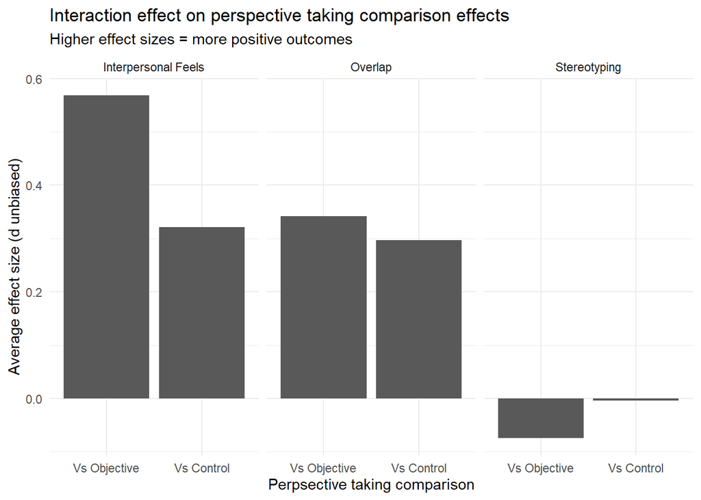

```r
emmeans_multi %>% ggplot(aes(x = pt_comparison, y = emmean)) +
  facet_grid(cols = vars(outcome_type)) +
  geom_col() +
  theme_minimal() +
  labs(title = "Interaction effect on perspective taking comparison effects",
       subtitle = "Higher effect sizes = more positive outcomes",
       x = "Perpsective taking comparison",
       y = "Average effect size (d unbiased)") +
  scale_x_discrete(labels = c('Vs Objective','Vs Control'))
```

The interpersonal feelings outcome results are consistent with McAuliffe’s findings for empathy/empathic concern (they found .68 for Imagine-other and .56 for Imagine-self vs objective, and we are collapsed across instructions here and with other effects to a .57). However, they found a lower average effect for Imagine-other vs no-instructions (.08) than our comparison versus the control (.32), but again, we have more results included. We also obtained our results in the interactive MLM model, not individual meta-analysis models as McAuliffe et al did. MLM models employ shrinkage on the estimates that would not occur when subsetting data down to the individual comparisons, which also accounts for differences between our results and McAuliffe results. This also allows us to retain a larger k.

```r
# Checking if model is over-parametized
# code is very slow, so will not include in markdown
par(mfrow=c(2,2))
profile(meta_multi2)
# Looks fine
```

## Heterogeneity

### I2 overall

#### Without paper

```r
get_I2_overall(meta_overall1, meta_multi1)
```

```
## [1] 91.14384
```

Overall heterogeneity is very high. 91.13% of the variance can be explained due to differences in the studies not explained by our predictors.

#### With paper

```r
get_I2_overall(meta_overall1, meta_multi2)
```

```
## [1] 91.35971
```

### I2 for levels of variance

*Left value corresponds to top sigma in Variance components output in model results (Sample_number_total). Right-most value corresponds to bottom sigma (Outcome_scale group).*

#### Without paper

```r
get_I2_levels(meta_multi1)
```

```
## [1] 43.49 35.55 12.18
```

Most of this heterogeneity is explained by between-study variance, followed by between-outcome (within-study) variance.

#### With paper

```r
get_I2_levels(meta_multi2)
```

```
## [1] 20.25 27.69 32.76 10.73
```

## Post-hoc Power

```r
subgroup_power(n_groups = 6,
               effect_sizes = c(.57, .32, .34, .30, -.07, -.001),
               sample_size = 120,
               k = 375,
               es_type = "d")
```

```
##
##  Power Analysis for Subgroup analysis:
##
##  Number of Groups:                  6
##  Groups:
##  Expected Effect Sizes:             0.57 0.32 0.34 0.3 -0.07 -0.001
##  Expected Sample Size (per group):  60
##  Expected Number of Studies:        375
##
##  Esimated Power to detect subgroup differences
##
##  Fixed-Effects Model:                  1
##  Random-Effects Model (i2 = 0%):       1
##  Random-Effects Model (i2 = 25%):      1
##  Random-Effects Model (i2 = 50%):      1
##  Random-Effects Model (i2 = 75%):      1
```

# Publication Bias

## Histograms of p-values

### Any outcome category

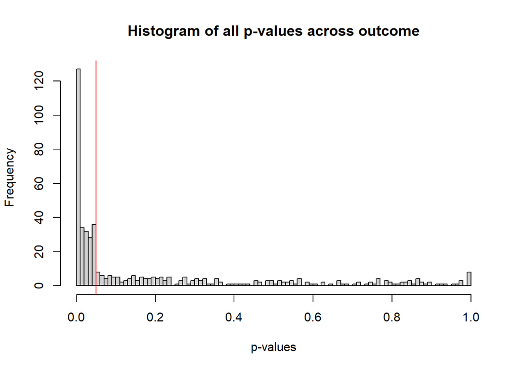

```r
p_val_data <- converted_data %>%
  select(authors, Year, study_num_total, study_num_per_article,
         sample_number_total, p_value, pt_comparison, interpersonl_subcategory) %>%
  mutate(p_value = as.numeric(p_value)) %>%
  na.omit() %>%
   mutate(p_val_cat = case_when(p_value <=.01 ~ "<=.01",
                               p_value >.01 & p_value <=.02 ~ ">.01 - <=.02",
                               p_value >.02 & p_value <=.05 ~ ">.02 - <=.05",
                               p_value >.05 & p_value <=.10 ~ ">.05 - <=.10",
                               p_value >.10 & p_value <=.30 ~ ">.10 - <=.30",
                               p_value >.30 & p_value <=.50 ~ ">.30 - <=.50",
                               p_value >.50 & p_value <=.70 ~ ">.50 - <=.70",
                               p_value >.70 & p_value <=.90 ~ ">.70 - <=.90",
                               p_value >.90 ~ ">.9"))


hist(p_val_data$p_value,
     main = "Histogram of all p-values across outcome",
     xlab = "p-values",
     xlim = c(0, 1.0),
     breaks = 100)
abline(v = .05, col="red", lwd=1, lty=1)
```

**Table of p-values:**

```r
p_val_table <- p_val_data %>%
  select(p_val_cat) %>%
  group_by(p_val_cat) %>%
  count() %>%
  mutate(p_val_cat = as.factor(p_val_cat))
p_val_table
```

```
## # A tibble: 9 x 2
## # Groups:   p_val_cat [9]
##   p_val_cat        n
##   <fct>        <int>
## 1 <=.01          127
## 2 >.01 - <=.02    34
## 3 >.02 - <=.05    96
## 4 >.05 - <=.10    29
## 5 >.10 - <=.30    71
## 6 >.30 - <=.50    36
## 7 >.50 - <=.70    28
## 8 >.70 - <=.90    35
## 9 >.9             16
```

**Percent of non-sig. p-values:**

```r
total_pvals <- sum(p_val_table$n)
nonsig_pvals_table <- p_val_table %>%
  filter(p_val_cat != "<=.01" &
           p_val_cat != ">.01 - <=.02" &
           p_val_cat !=">.02 - <=.05")
nonsig_pvals <- sum(nonsig_pvals_table$n)

# Amount of p-values that are not significant
nonsig_percent <- nonsig_pvals/total_pvals*100
nonsig_percent
```

```
## [1] 45.55085
```

**Percent of sig. p-values:**

```r
# Amount of p-values that are significant
100 - nonsig_percent
```

```
## [1] 54.44915
```

### Stereotyping

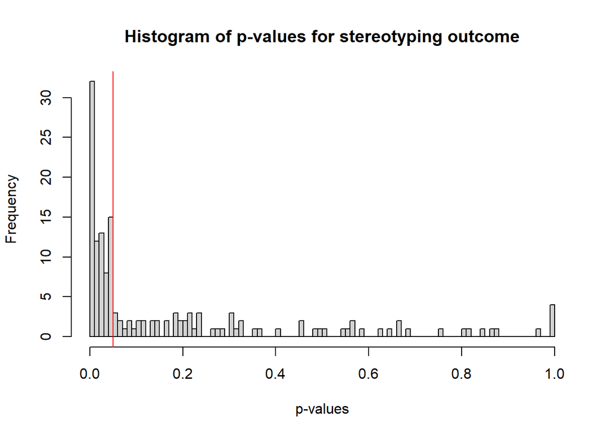

```r
stereo_p_val_data <- p_val_data %>%
  filter(interpersonl_subcategory == 1)

hist(stereo_p_val_data$p_value,
     main = "Histogram of p-values for stereotyping outcome",
     xlab = "p-values",
     xlim = c(0, 1.0),
     breaks = 100)
abline(v = .05, col="red", lwd=1, lty=1)
```

**Table of p-values:**

```r
p_val_table_stereo <- stereo_p_val_data %>%
  select(p_val_cat) %>%
  group_by(p_val_cat) %>%
  count() %>%
  mutate(p_val_cat = as.factor(p_val_cat))
p_val_table_stereo
```

```
## # A tibble: 9 x 2
## # Groups:   p_val_cat [9]
##   p_val_cat        n
##   <fct>        <int>
## 1 <=.01           32
## 2 >.01 - <=.02    12
## 3 >.02 - <=.05    36
## 4 >.05 - <=.10     9
## 5 >.10 - <=.30    27
## 6 >.30 - <=.50    13
## 7 >.50 - <=.70    11
## 8 >.70 - <=.90     6
## 9 >.9              5
```

**Percent of non-sig. p-values:**

```r
stereo_total_pvals <- sum(p_val_table_stereo$n)
stereo_nonsig_pvals_table <- p_val_table_stereo %>%
  filter(p_val_cat != "<=.01" &
           p_val_cat != ">.01 - <=.02" &
           p_val_cat !=">.02 - <=.05")
stereo_nonsig_pvals <- sum(stereo_nonsig_pvals_table$n)

# Amount of p-values that are not significant
stereo_nonsig_percent <- stereo_nonsig_pvals/stereo_total_pvals*100
stereo_nonsig_percent
```

```
## [1] 47.01987
```

**Percent of sig. p-values:**

```r
# Amount of p-values that are significant
100 - stereo_nonsig_percent
```

```
## [1] 52.98013
```

### Merging/Overlap

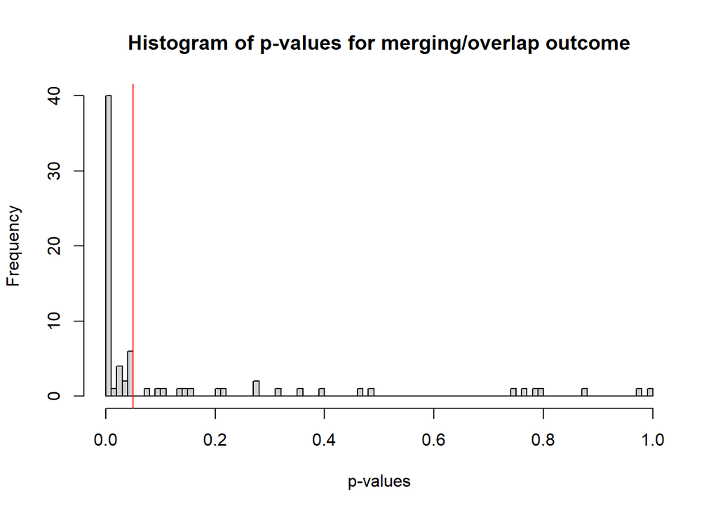

```r
overlap_p_val_data <- p_val_data %>%
  filter(interpersonl_subcategory == 2)

hist(overlap_p_val_data$p_value,
     main = "Histogram of p-values for merging/overlap outcome",
     xlab = "p-values",
     xlim = c(0, 1.0),
     breaks = 100)
abline(v = .05, col="red", lwd=1, lty=1)
```

**Table of p-values:**

```r
overlap_p_val_data %>%
  select(p_val_cat) %>%
  group_by(p_val_cat) %>%
  count()
```

```
## # A tibble: 8 x 2
## # Groups:   p_val_cat [8]
##   p_val_cat        n
##   <chr>        <int>
## 1 <=.01           40
## 2 >.01 - <=.02     1
## 3 >.02 - <=.05    12
## 4 >.05 - <=.10     2
## 5 >.10 - <=.30     8
## 6 >.30 - <=.50     5
## 7 >.70 - <=.90     5
## 8 >.9              2
```

```r
p_val_table_overlap <- overlap_p_val_data %>%
  select(p_val_cat) %>%
  group_by(p_val_cat) %>%
  count() %>%
  mutate(p_val_cat = as.factor(p_val_cat))
p_val_table_overlap
```

```
## # A tibble: 8 x 2
## # Groups:   p_val_cat [8]
##   p_val_cat        n
##   <fct>        <int>
## 1 <=.01           40
## 2 >.01 - <=.02     1
## 3 >.02 - <=.05    12
## 4 >.05 - <=.10     2
## 5 >.10 - <=.30     8
## 6 >.30 - <=.50     5
## 7 >.70 - <=.90     5
## 8 >.9              2
```

**Percent of non-sig. p-values:**

```r
overlap_total_pvals <- sum(p_val_table_overlap$n)
overlap_nonsig_pvals_table <- p_val_table_overlap %>%
  filter(p_val_cat != "<=.01" &
           p_val_cat != ">.01 - <=.02" &
           p_val_cat !=">.02 - <=.05")
overlap_nonsig_pvals <- sum(overlap_nonsig_pvals_table$n)


# Amount of studies that are not significant
overlap_nonsig_percent <- overlap_nonsig_pvals/overlap_total_pvals*100
overlap_nonsig_percent
```

```
## [1] 29.33333
```

**Percent of sig. p-values:**

```r
# Amount of studies that are significant
100-overlap_nonsig_percent
```

```
## [1] 70.66667
```

### Interpersonal

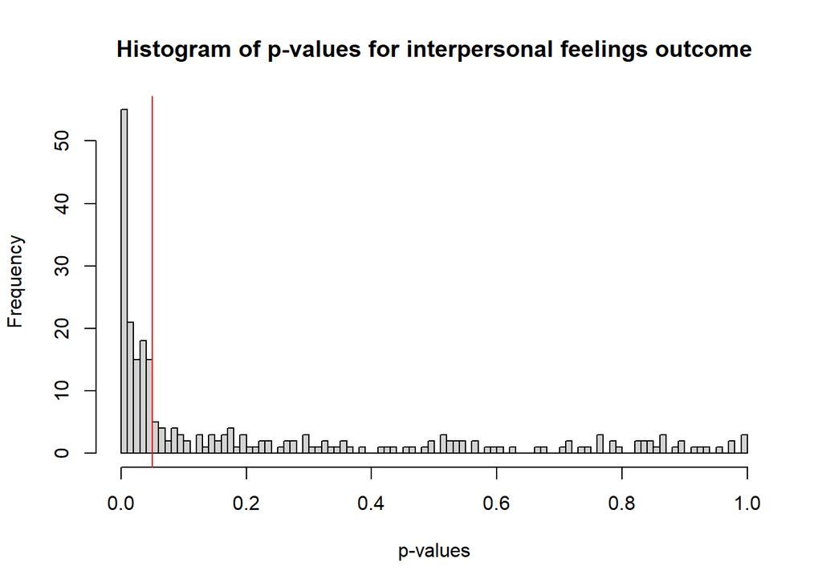

```r
intpersonal_p_val_data <- p_val_data %>%
  filter(interpersonl_subcategory == 3)

hist(intpersonal_p_val_data$p_value,
     main = "Histogram of p-values for interpersonal feelings outcome",
     xlab = "p-values",
     xlim = c(0, 1.0),
     breaks = 100)
abline(v = .05, col="red", lwd=1, lty=1)
```

**Table of p-values:**

```r
intpersonal_p_val_data %>%
  select(p_val_cat) %>%
  group_by(p_val_cat) %>%
  count()
```

```
## # A tibble: 9 x 2
## # Groups:   p_val_cat [9]
##   p_val_cat        n
##   <chr>        <int>
## 1 <=.01           55
## 2 >.01 - <=.02    21
## 3 >.02 - <=.05    48
## 4 >.05 - <=.10    18
## 5 >.10 - <=.30    36
## 6 >.30 - <=.50    18
## 7 >.50 - <=.70    17
## 8 >.70 - <=.90    24
## 9 >.9              9
```

```r
p_val_table_interpersonal <- intpersonal_p_val_data %>%
  select(p_val_cat) %>%
  group_by(p_val_cat) %>%
  count() %>%
  mutate(p_val_cat = as.factor(p_val_cat))
p_val_table_interpersonal
```

```
## # A tibble: 9 x 2
## # Groups:   p_val_cat [9]
##   p_val_cat        n
##   <fct>        <int>
## 1 <=.01           55
## 2 >.01 - <=.02    21
## 3 >.02 - <=.05    48
## 4 >.05 - <=.10    18
## 5 >.10 - <=.30    36
## 6 >.30 - <=.50    18
## 7 >.50 - <=.70    17
## 8 >.70 - <=.90    24
## 9 >.9              9
```

**Percent of non-sig. p-values:**

```r
interpersonal_total_pvals <- sum(p_val_table_interpersonal$n)
p_val_table_interpersonal_nosig <- p_val_table_interpersonal %>%
  filter(p_val_cat != "<=.01" &
           p_val_cat != ">.01 - <=.02" &
           p_val_cat !=">.02 - <=.05")
interpersonal_nonsig_pvals <- sum(p_val_table_interpersonal_nosig$n)

# Amount of p-values that are non-significant
interpersonal_nonsig_percent <- interpersonal_nonsig_pvals/interpersonal_total_pvals*100
interpersonal_nonsig_percent
```

```
## [1] 49.5935
```

**Percent of sig. p-values:**

```r
# Amount of p-values that are significant
100 - interpersonal_nonsig_percent
```

```
## [1] 50.4065
```

## Egger’s MLM - Overall Model

```r
# Getting modified covariate that removes artifactual correlation between SMD ES and its related variance
eggers_data <- meta_overall1 %>%
    mutate(Va = 4/(n_overall),
         sda = sqrt(Va),
         sdi = sqrt(var_dunb))

# Adapted from Rodgers & Putjevosky (2019) https://osf.io/7ak2m/?view_only=e74f9ddad3834e0e8c0bae9ef6b0441c

mlma_egg_mod_sda <- rma.mv(dunb ~ 1 + sda,
                           V = var_dunb,
                           random = list(~ 1 | authors/sample_number_total/outcomes_within_sample_var,
                                    ~ 1 | outcome_scale_group),
                           data = eggers_data, test = "t")


mlma_egg_mod_se <- rma.mv(dunb ~ 1 + sdi,
                           V = var_dunb,
                           random = list(~ 1 | authors/sample_number_total/outcomes_within_sample_var,
                                    ~ 1 | outcome_scale_group),
                           data = eggers_data, test = "t")


mlma_results_sda <- with(mlma_egg_mod_sda, data.frame(Egger_test = "Modified Covariate",
                                                      beta = b[2],
                                                      se = se[2],
                                                      p_val = pt(zval[2], dfs, lower.tail = FALSE))) #this is the t-value

mlma_results_se <- with(mlma_egg_mod_se, data.frame(Egger_test = "Standard Error",
                                                    beta = b[2],
                                                    se = se[2],
                                                    p_val = pt(zval[2], dfs, lower.tail = FALSE))) #this is the t-value

egger_overall_results <- rbind(mlma_results_sda, mlma_results_se)
egger_overall_results
```

```
##           Egger_test      beta        se               p_val
## 1 Modified Covariate 0.8134192 0.6365951 0.10106128188301498
## 2     Standard Error 3.4652035 0.5218732 0.00000000005518065
```